# Peramalan Jumlah Perjalanan Wisatawan Nusantara pada Provinsi Jawa Timur Menggunakan Metode Holt-Winters Exponential Smoothing

Dataset diambil dari [Badan Pusat Statistik](https://www.bps.go.id/id).

Peramalan ini menggunakan dataset **Jumlah Perjalanan Wisatawan Nusantara** mulai tahun 2020 sampai dengan 2024 yang berisi 60 data dan 34 provinsi. Peramalan akan menggunakan metode Holt-Winters Exponential Smoothing dengan provinsi yang akan diramal adalah **Jawa Timur**

Holt-Winters Exponential Smoothing adalah metode peramalan yang digunakan untuk memprediksi data di masa depan berdasarkan pola data historis. Metode ini sangat cocok untuk data yang memiliki tren dan musiman.

**Peramalan Jumlah Perjalanan Wisatawan Nusantara Provinsi Jawa Timur**

**1. Mengimport Library yang Akan Digunakan**

```r
library(forecast)
```

```r
library(ggplot2)
```

**2. Membaca Dataset dan Menampilkan Dataset**

```r
# Membaca Dataset
data = read.csv("~/Jumlah Perjalanan Wisatawan Nusantara Menurut Provinsi Tujuan, 2024.csv")

# Menampilkan Dataset
head(data)
```

```
##             Bulan    ACEH SUMATERA.UTARA SUMATERA.BARAT    RIAU  JAMBI
## 1  Januari (2024) 1009785        4055407        1767621 1546102 665652
## 2 Februari (2024)  937728        3392029        1758610 1449021 610850
## 3    Maret (2024)  905565        3149185        1281044 1434953 612554
## 4    April (2024) 1282532        3548654        1660760 1750903 886241
## 5      Mei (2024)  995794        3419857        1302524 1488391 662793
## 6     Juni (2024) 1065780        3369808        1642366 1446350 665827
##   SUMATERA.SELATAN BENGKULU LAMPUNG KEP..BANGKA.BELITUNG KEP..RIAU DKI.JAKARTA
## 1          1425715   361373 1618490               250498    291092     6575224
## 2          1319045   308036 1338941               237943    290290     6591103
## 3          1285518   298351 1260766               224732    268990     6516141
## 4          1854471   477429 1702675               297882    333667     6717681
## 5          1326810   339591 1508526               237959    276392     7003491
## 6          1361245   358206 1658113               235572    241548     6400253
##   JAWA.BARAT JAWA.TENGAH DI.YOGYAKARTA JAWA.TIMUR  BANTEN    BALI
```

[output cut: 34 more lines]

**3. Mengambil Provinsi Jawa Timur dari Dataset**

```r
data_jatim = data$JAWA.TIMUR
head(data_jatim)
```

```
## [1] 18995177 18581675 16845753 25059729 18654895 19889602
```

**4. Mengecek Isi Data Provinsi Jawa Timur**

```r
# Rangkuman Provinsi Jawa Timur
summary(data_jatim)
```

```
##     Min.  1st Qu.   Median     Mean  3rd Qu.     Max.
##  6570521 12392496 14700202 15209069 18599980 27190607
```

```r
# Melihat Struktur Data
str(data_jatim)
```

```
##  int [1:60] 18995177 18581675 16845753 25059729 18654895 19889602 17652253 14587397 15450635 16365062 ...
```

```r
# Merubah Nilai Integer Menjadi Numeric
data_jatim = as.numeric(data_jatim)
# Melihat Kembali Struktu Datanya
str(data_jatim)
```

```
##  num [1:60] 18995177 18581675 16845753 25059729 18654895 ...
```

```r
# Melihat Apakah ada Missing Value
sum(is.na(data_jatim))
```

```
## [1] 0
```

**5. Membuat Visualisasi untuk Data Jawa Timur**

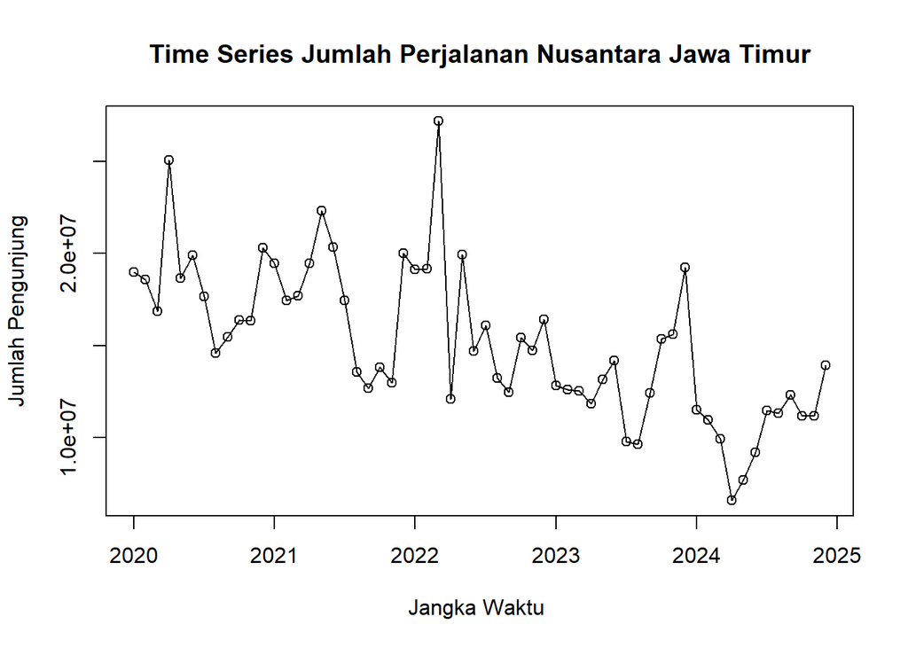

```r
timeseries_jatim <- ts(data_jatim, start = c(2020, 1), frequency = 12)

ts.plot(timeseries_jatim, xlab="Jangka Waktu ", ylab="Jumlah Pengunjung",
main= "Time Series Jumlah Perjalanan Nusantara Jawa Timur")
points(timeseries_jatim)
```

**6. Melihat Boxplot Untuk Dataset Jawa Timur**

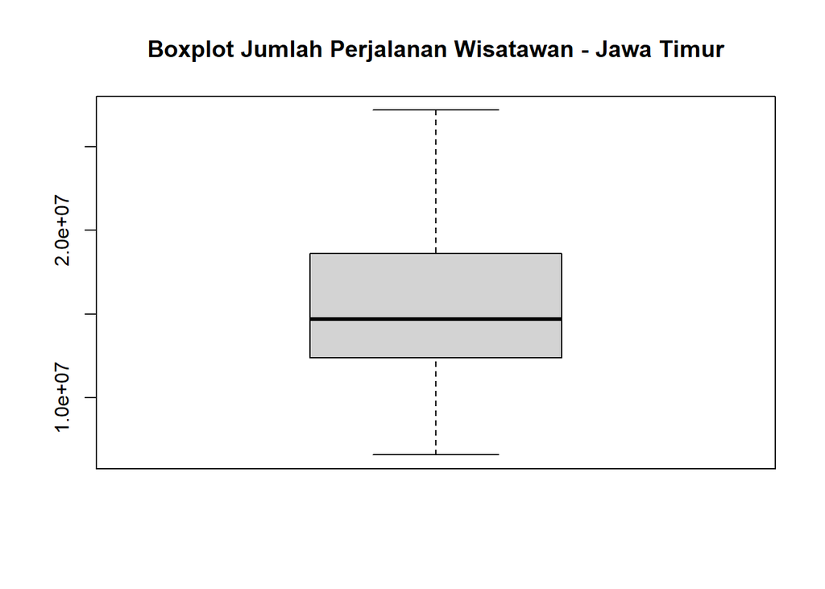

```r
boxplot(timeseries_jatim, main = "Boxplot Jumlah Perjalanan Wisatawan - Jawa Timur")
```

Dari visualisasi menggunakan bloxplot terlihat bahwa data:

1. Data jumlah perjalanan wisatawan provinsi Jawa Timur tidak memiliki outlier
2. Median Data jumlah perjalanan wisatawan provinsi Jawa Timur berada di sekitar 15 juta
3. Variabilitas pada data cukup besar, yang berarti jumlah perjalanan wisatawan bervariasi dari waktu ke waktu

**7. Melakukan Peramalan Menggunakan Metode Holt-Winters Exponential Smoothing**

```r
# Model Holt-Winters Exponential Smoothing
model_hw <- hw(timeseries_jatim, seasonal = "mult", h = 24)
print(model_hw$model)
```

```
## Holt-Winters' multiplicative method
##
## Call:
## hw(y = timeseries_jatim, h = 24, seasonal = "mult")
##
##   Smoothing parameters:
##     alpha = 0.0061
##     beta  = 1e-04
##     gamma = 0.001
##
##   Initial states:
##     l = 20188055.86
##     b = -166651.6869
##     s = 1.2767 0.9734 0.9492 0.8627 0.8319 0.9549
##            1.0276 1.0703 0.9963 1.0707 0.9786 1.0077
##
##   sigma:  0.2101
##
##      AIC     AICc      BIC
## 2054.656 2069.227 2090.259
```

Dari peramalan terlihat bahwa:

1. Peramalan menggunakan metode Holt-Winters Exponential Smoothing dan menggunakan data timeseries_jatim yang telah dibuat
2. Seasonal (musiman) merupakan pola berulang yang terjadi dalam data sepanjang waktu yang terbagi menjadi dua yaitu additive dan multiplicative. Pada peramalan kali ini seasonal menggunakan multiplicative karena data menunjukkan pola musiman yang bervariasi dari waktu ke waktu
3. h merupakan jumlah bulan yang akan diprediksi yang di mana pada peramalan ini akan memprediksi bagaimana data 24 bulan (2 tahun) ke depan
4. Terdapat parameter smoothing yang di mana nilai kecil menandakan model memberi bobot lebih besar pada data historis dibanding data terbaru.
   1. alpha = 0.0061, smoothing untuk level. Nilai kecil menunjukkan bahwa model tidak terlalu cepat menyesuaikan terhadap perubahan baru.
   2. beta = 1e-4, smoothing untuk tren.
   3. gamma = 0.001, smoothing untuk musiman.
5. Terdapat initial states:
   1. l = 20188055.86, yang merupakan nilai level awal
   2. b = -166651.6869, yang merupakan nilai tren awal
   3. s = faktor musiman awal untuk 12 bulan, ditunjukkan oleh serangkaian nilai musiman yang berulang
6. Terdapat sigma = 0.2101, yang merupakan estimasi kesalahan model yang menunjukkan seberapa besar penyimpangan antara hasil prediksi dengan data aktual
7. Terdapat AIC, AICc, dan BIC yang di mana semakin kecil nilainya semakin baik modelnya

**8. Evaluasi Model Holt-Winters Exponential Smoothing Menggunakan MAPE, RMSE, dan MAE**

```r
# Melihat Hasil Model
akurasi_model = accuracy(model_hw)
df_akurasi_model = data.frame(akurasi_model)

# Hasil MAPE
df_akurasi_model$MAPE
```

```
## [1] 14.353
```

```r
# Hasil RMSE
df_akurasi_model$RMSE
```

```
## [1] 2645937
```

```r
# Hasil MAE
df_akurasi_model$MAE
```

```
## [1] 2048400
```

Dari hasil evaluasi model menggunakan MAPE, RMSE, dan MAE diatas menggunakan fungsi accuracy() diketahui bahwa:

1. MAPE (Mean Absolute Percentage Error) merupakan rata-rata presentase kesalahan absolute antara nilai aktual dengan nilai prediksi. Dari model peramalan yang telah dibuat didapat nilai MAPE sebesar 14.353 (14.3 %) yang berada di rentang 10% - 20% yang artinya model sudah baik untuk memprediksi jumlah perjalanan wisatawan
2. RMSE (Root Mean Square Error) merupakan Akar dari rata-rata kuadrat kesalahan antara nilai aktual dan nilai prediksi. Dari model peramalan yang telah dibuat didapat nilai RMSE sebesar 2.645.937 yang di mana lebih kecil dari rata-rata data sesungguhnya
3. MAE (Mean Absolute Error) merupakan Rata-rata kesalahan absolut antara nilai aktual dan nilai prediksi. Dari model peramalan yang telah dibuat didapat nilai MAE sebesar 2.048.400 yang di mana lebih kecil dari rata-rata data sesungguhnya
4. Dari beberapa penjelasan diatas model peramalan sudah cukup baik untuk memprediksi data jumlah perjalanan wisatawan beberapa tahun ke depan

**9. Visualisasi Hasil dari Peramalan**

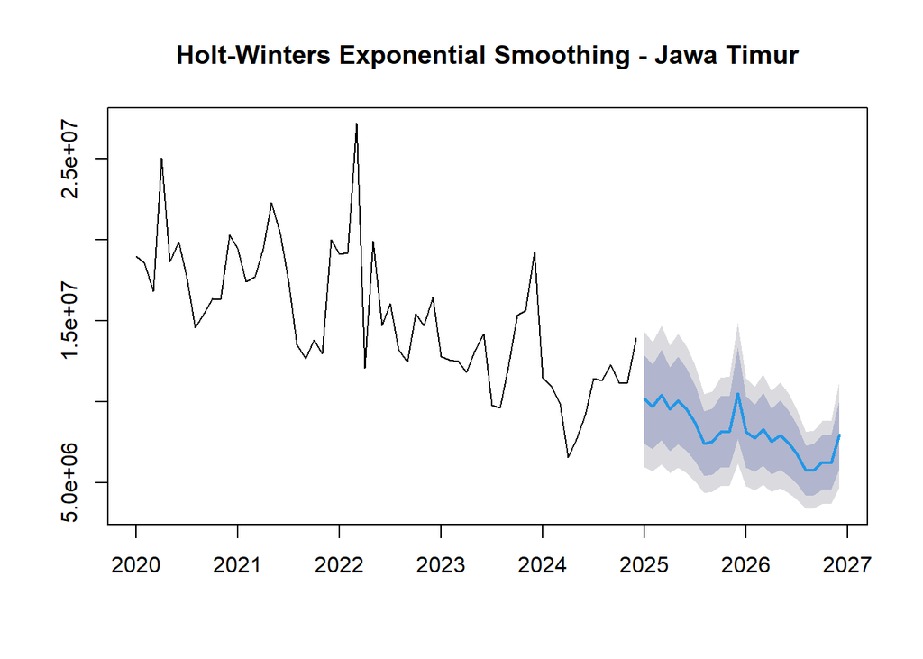

```r
plot(model_hw, main = "Holt-Winters Exponential Smoothing - Jawa Timur")
```

Dari visualisasi peramalan menggunakan metode Holt-Winters Exponential Smoothing dapat dilihat:

**10. Melihat Hasil Peramalan**

```r
print(model_hw$mean)
```

```
##           Jan      Feb      Mar      Apr      May      Jun      Jul      Aug
## 2025 10152309  9696202 10430878  9537122 10069734  9498429  8669305  7414479
## 2026  8145413  7747364  8298665  7553821  7938743  7452255  6767603  5757751
##           Sep      Oct      Nov      Dec
## 2025  7547367  8147227  8191911 10531548
## 2026  5828948  6256353  6253169  7988949
```

**11. Kesimpulan**

Dari model peramalan yang telah dibuat menggunakan metode Holt-Winters Exponential Smoothing didapat bahwa:

1. Metode peramalan menggunakan Holt-Winters Exponential Smoothing dengan seasonal multiplicative cocok dengan dataset yang digunakan dan berhasil menangkap pola tren dan musiman yang ada di provinsi Jawa Timur
2. Dari hasil evaluasi model menggunakan MAPE, RMSE, dan MAE didapat nilai yang cukup kecil yang artinya model sudah cukup baik untuk memprediksi data jumlah perjalanan wisatawan nusantara
3. Hasil visualisasi dari model menunjukkan gambaran yang jelas mengenai bagaimana bentuk tren beberapa tahun ke depan